# Homework 12

Ismam Ferdous

2025-12-05

## Q1

Revisiting the penguins dataset, do the following **for each species** using tidyverse syntax:

1. Remake the bar plot showing average body mass for each species and for each sex (you can just copy the code from section 8.1.1 of the notes if you wish).
2. Construct and interpret 95% confidence intervals for the mean difference in body mass (male–female).
3. Do a standard α=0.05 level hypothesis test to see if male penguins are heavier on average than female penguins.

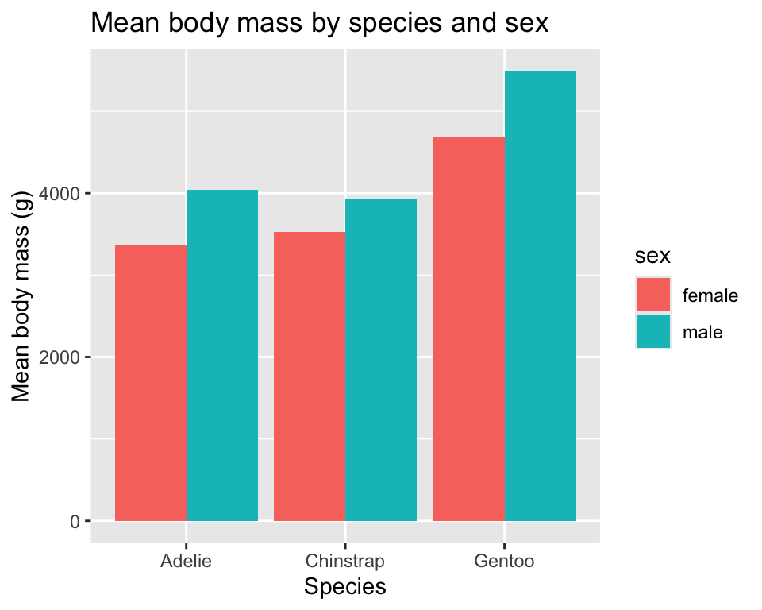

```r
# a. bar plot :
penguins <- read_csv("https://bwu62.github.io/stat240-revamp/data/penguins.csv")
penguins %>%
  group_by(species, sex) %>%
  summarize(mean_mass = mean(body_mass_g), .groups = "drop") %>%
  ggplot(aes(x = species, y = mean_mass, fill = sex)) +
  geom_col(position = "dodge") +
  labs(
    x = "Species",
    y = "Mean body mass (g)",
    title = "Mean body mass by species and sex"
  )
```

```r
# b. CI's

penguin_diff <- penguins %>%
  group_by(species, sex) %>%
  summarize(
    mean_mass = mean(body_mass_g),
    sd_mass   = sd(body_mass_g),
    n         = n(),
    .groups = "drop"
  ) %>%
  pivot_wider(
    names_from = sex,
    values_from = c(mean_mass, sd_mass, n)
  ) %>%
  mutate(
    diff_mean = mean_mass_male - mean_mass_female,
    se_diff = sqrt(
      sd_mass_male^2 / n_male + sd_mass_female^2 / n_female
    ),
    t_crit = qt(0.975, df = n_male + n_female - 2),
    ci_low  = diff_mean - t_crit * se_diff,
    ci_high = diff_mean + t_crit * se_diff
  )

penguin_diff
```

```
## # A tibble: 3 × 12
##   species   mean_mass_female mean_mass_male sd_mass_female sd_mass_male n_female
##   <chr>                <dbl>          <dbl>          <dbl>        <dbl>    <int>
## 1 Adelie               3369.          4043.           269.         347.       73
## 2 Chinstrap            3527.          3939.           285.         362.       34
## 3 Gentoo               4680.          5485.           282.         313.       58
## # ℹ 6 more variables: n_male <int>, diff_mean <dbl>, se_diff <dbl>,
## #   t_crit <dbl>, ci_low <dbl>, ci_high <dbl>
```

```r
#c. c. Hypothesis tests if the males are heavier?

penguin_tests <- penguins %>%
  group_by(species) %>%
  summarize(
    t_test = list(t.test(
      body_mass_g ~ sex,
      data = cur_data(),
      alternative = "greater",
      var.equal = TRUE
    )),
    .groups = "drop"
  ) %>%
  mutate(
    t_stat = map_dbl(t_test, "statistic"),
    p_value = map_dbl(t_test, "p.value")
  ) %>%
  select(species, t_stat, p_value)
penguin_tests
```

```
## # A tibble: 3 × 3
##   species   t_stat p_value
##   <chr>      <dbl>   <dbl>
## 1 Adelie    -13.1    1
## 2 Chinstrap  -5.21   1.000
## 3 Gentoo    -14.7    1
```

## Q2

From the `MASS` package, load in the `cats` dataset (just install & import the package and you should have it). This dataset contains body weight (kg) and heart weight (g) data from a sample of domestic cats. For the rest of the problem, consider body weight as the predictor and heart weight as the response.

1. Plot the dataset, additionally using color to distinguish the `Sex` of the cats. Does there appear to be strong differences between the sexes?
2. Compute the correlation coefficient both manually and using R for this dataset. Does there appear to be a strong linear relationship, and in what direction?
3. Compute the best fit coefficients both manually and using R’s `lm()` function, and print the summary output.
4. Check the residual plots of the fit. Does the model appear well fit?
5. Compute both a 95% confidence interval for the true slope and run a standard α=0.05 level significant test for the fitted slope vs 0. Does there appear to be significant linear relationship?
6. Find a 95% confidence interval for the mean heart weight of 8-pound cats.
7. You rescue a new cat who’s approximately 8 pounds. Give a 95% prediction interval for its heart weight.

```r
library(MASS)
```

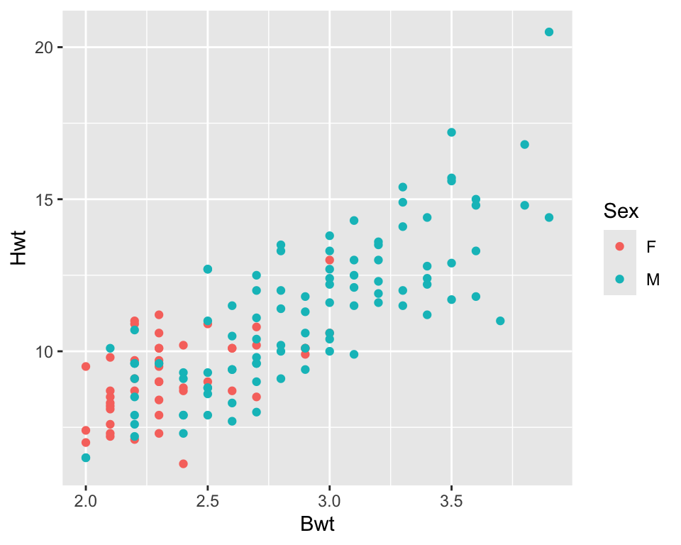

```r
data(cats)

#a. plotting :

ggplot(cats, aes(x = Bwt, y = Hwt, color = Sex)) +
  geom_point()
```

```r
#b. correlation coefficient :

# manual
r_manual <- with(cats, cor(Bwt, Hwt))

# or directly
cor_BH <- cor(cats$Bwt, cats$Hwt)
r_manual; cor_BH
```

```
## [1] 0.8041274
```

```
## [1] 0.8041274
```

```r
#c. the best fit line

fit <- lm(Hwt ~ Bwt, data = cats)
coef(fit)
```

```
## (Intercept)         Bwt
##  -0.3566624   4.0340627
```

```r
summary(fit)
```

```
##
## Call:
## lm(formula = Hwt ~ Bwt, data = cats)
##
## Residuals:
##     Min      1Q  Median      3Q     Max
## -3.5694 -0.9634 -0.0921  1.0426  5.1238
##
## Coefficients:
##             Estimate Std. Error t value Pr(>|t|)
## (Intercept)  -0.3567     0.6923  -0.515    0.607
## Bwt           4.0341     0.2503  16.119   <2e-16 ***
## ---
## Signif. codes:  0 '***' 0.001 '**' 0.01 '*' 0.05 '.' 0.1 ' ' 1
##
## Residual standard error: 1.452 on 142 degrees of freedom
## Multiple R-squared:  0.6466, Adjusted R-squared:  0.6441
## F-statistic: 259.8 on 1 and 142 DF,  p-value: < 2.2e-16
```

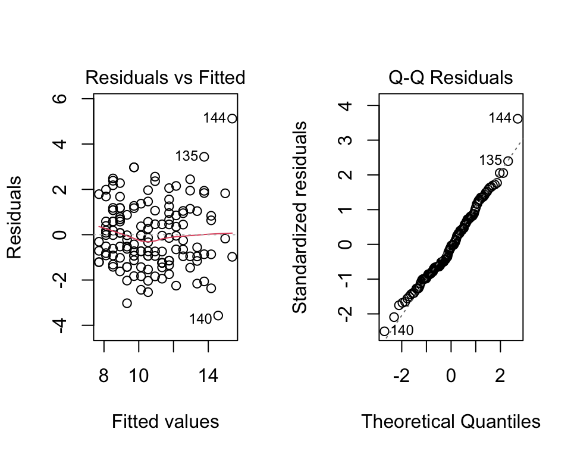

```r
#d . residual plots
par(mfrow = c(1, 2))
plot(fit, which = 1)  # residuals vs fitted
plot(fit, which = 2)  # normal Q–Q
```

```r
par(mfrow = c(1, 1))


#e. inference for the slopes :

confint(fit, level = 0.95)  # 95% CI for intercept and slope
```

```
##                 2.5 %   97.5 %
## (Intercept) -1.725163 1.011838
## Bwt          3.539343 4.528782
```

```r
summary(fit)$coefficients   # includes t-test and p-value for slope
```

```
##               Estimate Std. Error    t value     Pr(>|t|)
## (Intercept) -0.3566624  0.6922770 -0.5152019 6.072131e-01
## Bwt          4.0340627  0.2502615 16.1193908 6.969045e-34
```

```r
#f. CI for mean hearts weight at 8lbs :

new_cat <- data.frame(Bwt = 8 / 2.2)
predict(fit, newdata = new_cat, interval = "confidence", level = 0.95)
```

```
##        fit      lwr      upr
## 1 14.31266 13.80163 14.82368
```

```r
#g, PU for a single 8lb cat :

predict(fit, newdata = new_cat, interval = "prediction", level = 0.95)
```

```
##        fit      lwr      upr
## 1 14.31266 11.39646 17.22885
```